# MBA em Ciência de Dados - Estatística para Ciência de Dados

## Avaliação Final - Primeira questão

**Aluno**: Rafael Capaci Pereira

**Professora e Professor:** Cibele Russo e Francisco Rodrigues

**Cemeai - ICMC/USP São Carlos**

### Enunciado da questão

Uma empresa de market digital acredita que o tempo médio para um cliente responder a uma propaganda é maior do que 20 horas. Para analisar essa hipótese, são selecionados dados de 20 clientes, onde obtém-se os valores: 22,21,19,18,24,17,20,22,23,19,21,25,20,21,22,18,24,20,21,19. Suponha que o tempo de resposta tem distribuição normal com desvio padrão de 5 horas.

Teste a seguinte hipótese ao nível de 5%: H0:μ=20 H1:μ>20.

Resolva esse problema usando simulação, conforme feito na aula. Considere Ns=1000 simulações.

### Desenvolvimento da resposta

```python
import numpy as np
import matplotlib.pyplot as plt
import seaborn as sns

%matplotlib inline
```

```python
# Paleta de cores, disponível em https://coolors.co/edae49-d1495b-00798c-30638e-003d5b
colors = ["#edae49","#d1495b","#00798c","#30638e","#003d5b"]
```

```python
rng = np.random.default_rng(seed=13)
```

Primeiramente, vamos gerar as 1000 simulações, sorteando amostras de tamanho 20.

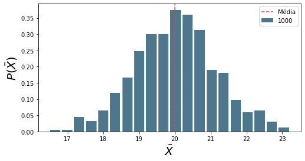

```python
mu = 20 # hipotese a ser testada
sigma = 5 # desvio padrao populacional
n = 20 #tamanho da amostra
Ns = 1000 # numero de simulacoes
Xm=[] #distribuicao da media amostral
for s in range(1, Ns):
    x = rng.normal(mu, sigma, n) # sorteia uma amostra de tamanho n
    Xm.append(np.mean(x))


plt.figure(figsize=(8,4))
# a = plt.hist(x=Xm, bins=20, color='#0504aa', alpha=0.7, rwidth=0.85, label = str(Ns), density=True)
a = plt.hist(x=Xm, bins=20, color=colors[-1], alpha=0.7, rwidth=0.85, label = str(Ns), density=True)
plt.axvline(x=mu, color=colors[1], linestyle='--', label='Média')
plt.xlabel(r'$\bar{X}$', fontsize=20)
plt.ylabel(r'$P(\bar{X})$', fontsize=20)

plt.legend()


plt.show(True)
```

```python
X = [22, 21, 19, 18, 24, 17, 20, 22, 23, 19, 21, 25, 20, 21, 22, 18, 24, 20, 21, 19]

xobs = np.mean(X)

alpha = 95
xc = np.percentile(Xm, alpha)
print('Xc=',xc,'  Xobs = ', xobs)
if(xobs < xc):
    print("Aceitamos H0")
else:
    print("Rejeitamos H0")
```

```
Xc= 21.75521927982985   Xobs =  20.8
Aceitamos H0
```

Como o $X_c=21.75$ e a média da amostra é $Xobs=20.8$, a hipótese $H0$ é aceita.

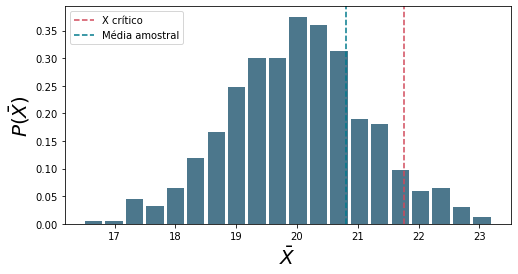

```python
plt.figure(figsize=(8,4))
a = plt.hist(x=Xm, bins=20, color=colors[-1], alpha=0.7, rwidth=0.85, density=True)
plt.axvline(x=xc, color=colors[1], linestyle='--', label = 'X crítico')
plt.axvline(x=xobs, color=colors[2], linestyle='--', label = 'Média amostral')
plt.xlabel(r'$\bar{X}$', fontsize=20)
plt.ylabel(r'$P(\bar{X})$', fontsize=20)
plt.legend()
plt.show()
```

* Os códigos presentes nesse documento foram retirados da Aula 5 do Professor Francisco, da disciplina de Estatística para Ciência de Dados.